# Missing Data

# Looking for patterns in missing data

## row / column patterns

- Do all variables have the same percentage of values missing?
- Are there row patterns to the missing values?

# Create a dataset with missing values

```r
# Add NAs to mtcars dataset
set.seed(5702)
mycars <- mtcars
mycars[,"gear"] <- NA
mycars[10:20, 3:5] <- NA
for (i in 1:10) mycars[sample(32,1), sample(11,1)] <- NA
```

# Row / column missing patterns

## Missing values by column

```r
colSums(is.na(mycars)) %>%
  sort(decreasing = TRUE)
```

```
## gear   hp drat disp qsec  mpg  cyl   vs   am   wt carb
##   32   12   12   11    2    1    1    1    1    0    0
```

# Row / column missing patterns

## Missing values by row

```r
rowSums(is.na(mycars)) %>%
  sort(decreasing = TRUE)
```

```
##            Merc 280           Merc 280C          Merc 450SE
##                   4                   4                   4
##          Merc 450SL         Merc 450SLC  Cadillac Fleetwood
##                   4                   4                   4
## Lincoln Continental   Chrysler Imperial            Fiat 128
##                   4                   4                   4
##         Honda Civic      Toyota Corolla   Hornet Sportabout
##                   4                   4                   2
##             Valiant          Duster 360       Toyota Corona
##                   2                   2                   2
##    Dodge Challenger         AMC Javelin           Fiat X1-9
##                   2                   2                   2
##          Volvo 142E           Mazda RX4       Mazda RX4 Wag
##                   2                   1                   1
##          Datsun 710      Hornet 4 Drive           Merc 240D
##                   1                   1                   1
##            Merc 230          Camaro Z28    Pontiac Firebird
##                   1                   1                   1
##       Porsche 914-2        Lotus Europa      Ford Pantera L
##                   1                   1                   1
##        Ferrari Dino       Maserati Bora
##                   1                   1
```

# Row / column missing patterns

## heatmap

`geom_tile()`

```r
library(tidyverse)

tidycars <- mycars %>%
    rownames_to_column("id") %>%
    gather(key, value, -id) %>%
    mutate(missing = ifelse(is.na(value), "yes", "no"))
```

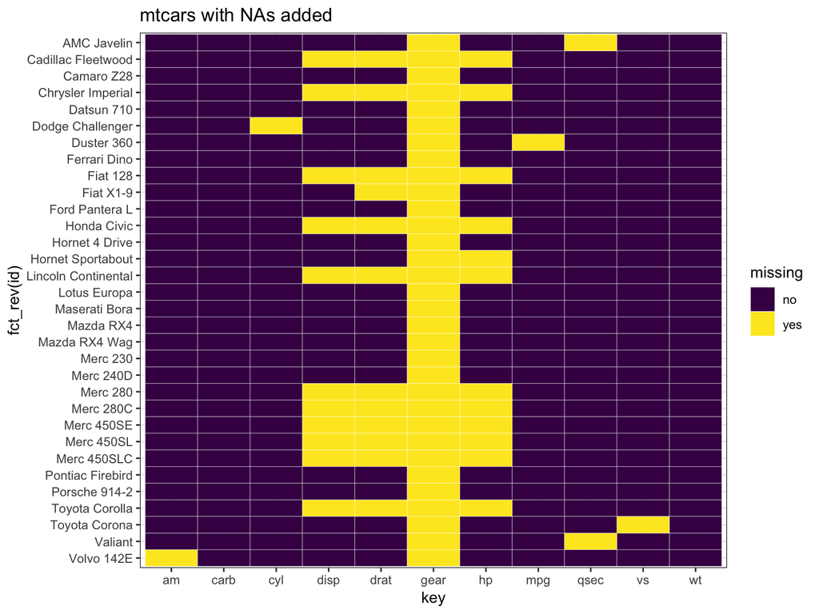

```r
ggplot(tidycars, aes(x = key, y = fct_rev(id), fill = missing)) +
  geom_tile(color = "white") +
  ggtitle("mtcars with NAs added") +
  scale_fill_viridis_d() + # discrete scale
  theme_bw()
```

# Row / column missing patterns

## heatmap

`mi::missing_data.frame()`

```r
library(mi)
x <- missing_data.frame(mycars)
```

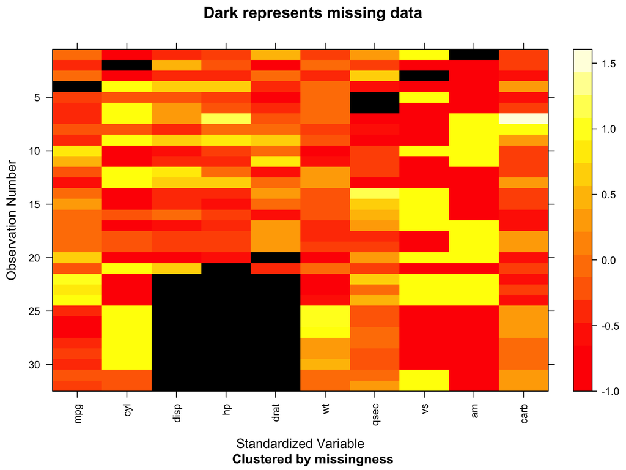

```r
image(x)
```

(gear not shown since all are missing)

# Row / column missing patterns

## Missing values by variable

`geom_tile()`

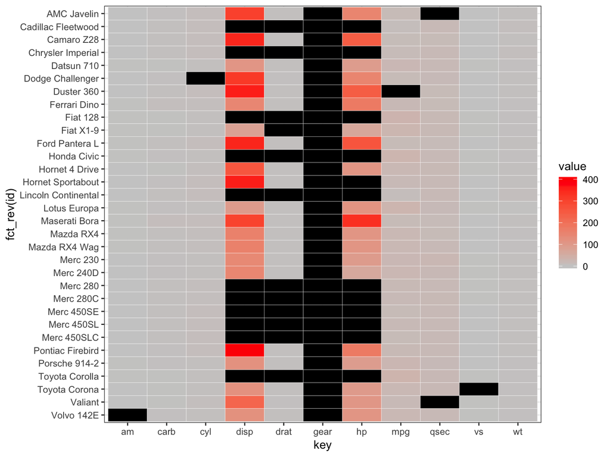

```r
ggplot(tidycars, aes(x = key, y = fct_rev(id), fill = value)) +
  geom_tile(color = "white") +
  scale_fill_gradient(low = "grey80", high = "red", na.value = "black") + theme_bw()
```

# Row / column missing patterns

## Missing values by variable

`geom_tile()` with standardized variables

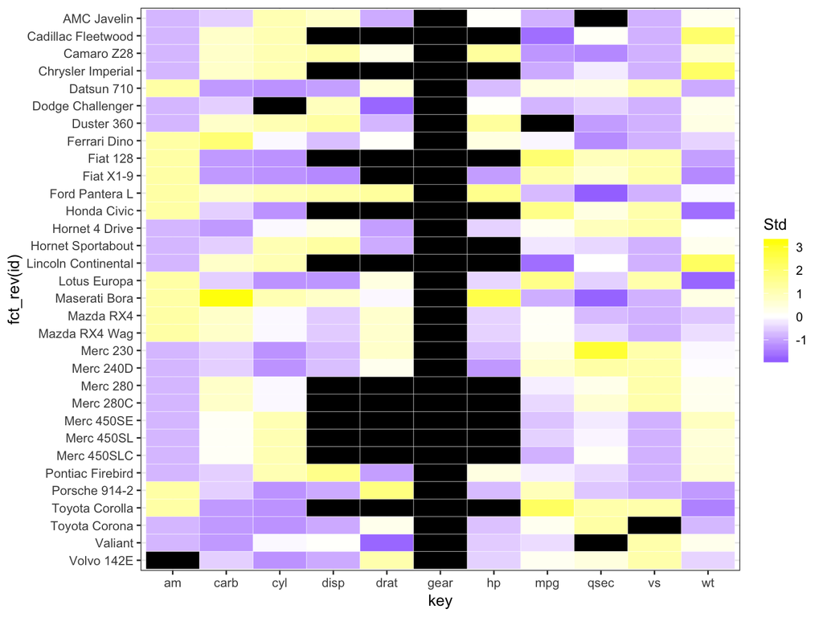

```r
tidycars <- tidycars %>% group_by(key) %>%
  mutate(Std = (value-mean(value, na.rm = TRUE))/sd(value, na.rm = TRUE)) %>% ungroup()

ggplot(tidycars, aes(x = key, y = fct_rev(id), fill = Std)) +
  geom_tile(color = "white") +
  scale_fill_gradient2(low = "blue", mid = "white", high ="yellow", na.value = "black") + theme_bw()
```

# Row / column missing patterns

## Missing values by variable

reordered by number of missing

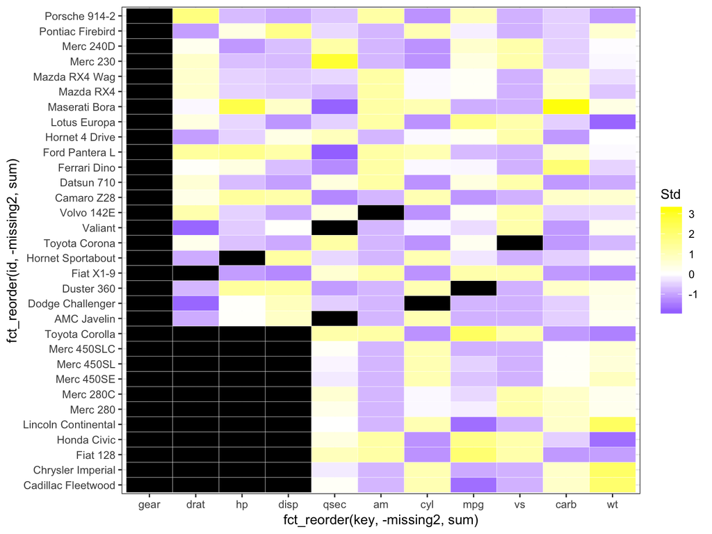

```r
# convert missing to numeric so it can be summed up
tidycars <- tidycars %>%
  mutate(missing2 = ifelse(missing == "yes", 1, 0))

ggplot(tidycars, aes(x = fct_reorder(key, -missing2, sum), y = fct_reorder(id, -missing2, sum), fill = Std)) +
  geom_tile(color = "white") +
  scale_fill_gradient2(low = "blue", mid = "white", high ="yellow", na.value = "black") + theme_bw()
```

# Row / column missing patterns

### Missing values by variable

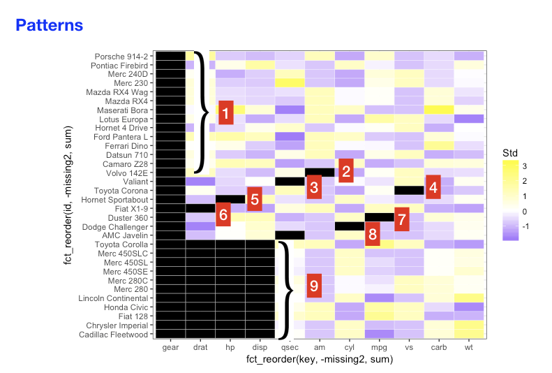

# Row / column missing patterns

### Missing values by variable

missing patterns

```r
x <- mi::missing_data.frame(mycars)
```

```
## NOTE: In the following pairs of variables, the missingness pattern of the first is a subset of the second.
##  Please verify whether they are in fact logically distinct variables.
##       [,1]   [,2]
##  [1,] "mpg"  "gear"
##  [2,] "cyl"  "gear"
##  [3,] "disp" "hp"
##  [4,] "disp" "drat"
##  [5,] "disp" "gear"
##  [6,] "hp"   "gear"
##  [7,] "drat" "gear"
##  [8,] "qsec" "gear"
##  [9,] "vs"   "gear"
## [10,] "am"   "gear"
```

```r
class(x)
```

```
## [1] "missing_data.frame"
## attr(,"package")
## [1] "mi"
```

```r
x@patterns
```

```
##  [1] nothing        nothing        nothing        nothing
##  [5] hp             qsec           mpg            nothing
##  [9] nothing        disp, hp, drat disp, hp, drat disp, hp, drat
## [13] disp, hp, drat disp, hp, drat disp, hp, drat disp, hp, drat
## [17] disp, hp, drat disp, hp, drat disp, hp, drat disp, hp, drat
## [21] vs             cyl            qsec           nothing
## [25] nothing        drat           nothing        nothing
## [29] nothing        nothing        nothing        am
## Levels: nothing hp qsec mpg vs cyl drat am disp, hp, drat
```

```r
levels(x@patterns)
```

```
## [1] "nothing"        "hp"             "qsec"           "mpg"
## [5] "vs"             "cyl"            "drat"           "am"
## [9] "disp, hp, drat"
```

```r
summary(x@patterns)
```

```
##        nothing             hp           qsec            mpg             vs
##             13              1              2              1              1
##            cyl           drat             am disp, hp, drat
##              1              1              1             11
```

# Row / column missing patterns

### Missing values by variable

missing patterns

(repeated patterns are reduced to one row)

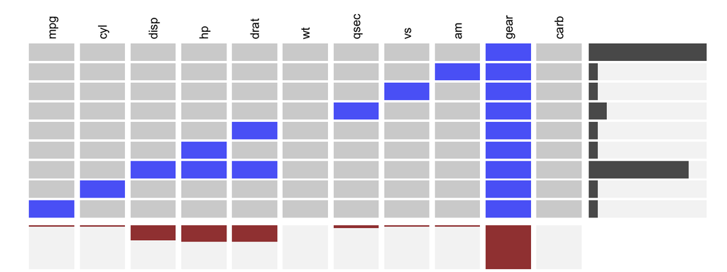

```r
library(extracat)
visna(mycars)
```

# visna() w/ row sort

Sorted by most common to least common missing *pattern* (top to bottom)

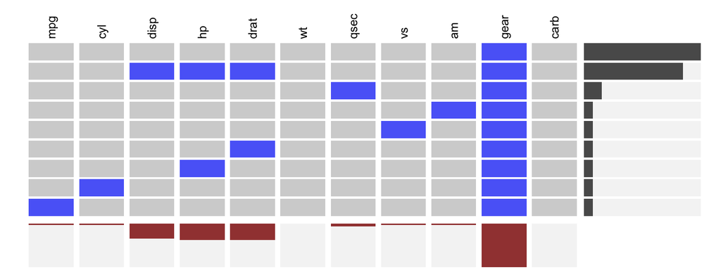

```r
visna(mycars, sort = "r")
```

# visna() w/ column sort

Sorted by *variable* with the most to least missing values (left to right)

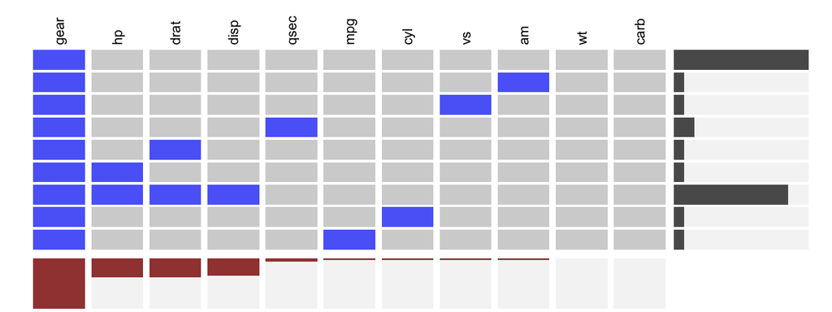

```r
visna(mycars, sort = "c")
```

# visna() w/ row & column sort

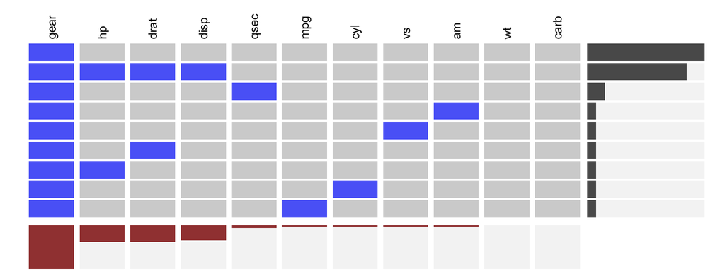

```r
visna(mycars, sort = "b")
```

# NYC School data

```r
df <- read.csv("SAT2010.csv", na.strings = "s",
               check.names = FALSE)
head(df)
```

| DBN | School Name | Number of Test Takers | Critical Reading Mean | Mathematics Mean | Writing Mean |
| --- | --- | --- | --- | --- | --- |
| 01M292 | Henry Street School for International Studies | 31 | 391 | 425 | 385 |
| 01M448 | University Neighborhood High School | 60 | 394 | 419 | 387 |
| 01M450 | East Side Community High School | 69 | 418 | 431 | 402 |
| 01M458 | SATELLITE ACADEMY FORSYTH ST | 26 | 385 | 370 | 378 |
| 01M509 | CMSP HIGH SCHOOL | NA | NA | NA | NA |
| 01M515 | Lower East Side Preparatory High School | 154 | 314 | 532 | 314 |

```r
dim(df)
```

```
## [1] 460   6
```

# NYC School data

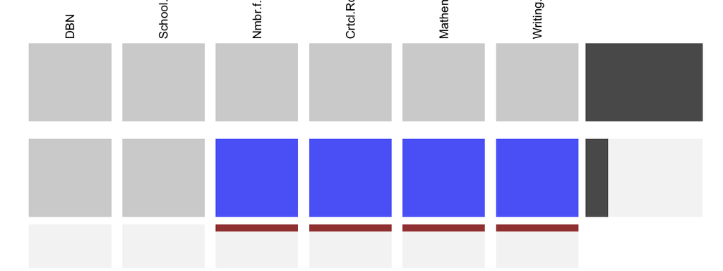

```r
visna(df)
```

# Looking for patterns in missing data

## value patterns

- Are missing patterns correlated with values of another variable?
- Are certain value ranges more likely to be missing?
- Or are there no patterns at all?

# NYC School data

Does the proportion of schools with missing data vary by borough?

Data: `SAT2010.csv`

# NYC School data

Does the proportion of schools with missing data vary by borough?

Data: `SAT2010.csv`

```r
head(df)
```

| DBN | School Name | Number of Test Takers | Critical Reading Mean | Mathematics Mean | Writing Mean |
| --- | --- | --- | --- | --- | --- |
| 01M292 | Henry Street School for International Studies | 31 | 391 | 425 | 385 |
| 01M448 | University Neighborhood High School | 60 | 394 | 419 | 387 |
| 01M450 | East Side Community High School | 69 | 418 | 431 | 402 |
| 01M458 | SATELLITE ACADEMY FORSYTH ST | 26 | 385 | 370 | 378 |
| 01M509 | CMSP HIGH SCHOOL | NA | NA | NA | NA |
| 01M515 | Lower East Side Preparatory High School | 154 | 314 | 532 | 314 |

# Missing by borough

```r
df <- df %>% mutate(Borough = str_sub(DBN, 3, 3))
percent_missing <- df %>% group_by(Borough) %>%
  summarize(num_schools = n(), num_na = sum(is.na(`Writing Mean`))) %>%
  mutate(percent_na = round(num_na/num_schools, 2)) %>%
  arrange(-percent_na)
percent_missing
```

| Borough | num_schools | num_na | percent_na |
| --- | --- | --- | --- |
| K | 141 | 32 | 0.23 |
| Q | 73 | 14 | 0.19 |
| M | 111 | 13 | 0.12 |
| X | 124 | 14 | 0.11 |
| R | 11 | 1 | 0.09 |

# Missing by borough

K, Q, M, X, R

Manhattan

Brooklyn

Queens

The Bronx

Staten Island

# Missing by borough

K, Q, M, X, R

Manhattan = New York County

Brooklyn = Kings County

Queens = Queens County

The Bronx = Bronx County

Staten Island = Richmond County

# Missing by borough

K, Q, M, X, R

Manhattan = New York County = “M”

Brooklyn = Kings County = “K”

Queens = Queens County = “Q”

The Bronx = Bronx County = “X”

Staten Island = Richmond County = “R”

# Missing by borough

```r
percent_missing <- percent_missing %>%
  mutate(BoroughName = fct_recode(Borough,
                                      Manhattan = "M",
                                      Brooklyn = "K",
                                      Queens = "Q",
                                      `The Bronx` = "X",
                                      `Staten Island` = "R"))
percent_missing
```

| Borough | num_schools | num_na | percent_na | BoroughName |
| --- | --- | --- | --- | --- |
| K | 141 | 32 | 0.23 | Brooklyn |
| Q | 73 | 14 | 0.19 | Queens |
| M | 111 | 13 | 0.12 | Manhattan |
| X | 124 | 14 | 0.11 | The Bronx |
| R | 11 | 1 | 0.09 | Staten Island |

# Missing by borough

```r
df <- df %>%
  mutate(BoroughName = fct_recode(Borough,
                                      Manhattan = "M",
                                      Brooklyn = "K",
                                      Queens = "Q",
                                      `The Bronx` = "X",
                                      `Staten Island` = "R"))

dfsum <- df %>% group_by(BoroughName) %>%
  summarize(Reading = round(mean(`Critical Reading Mean`, na.rm = TRUE), 1),
            Math = round(mean(`Mathematics Mean`, na.rm = TRUE), 1),
            Writing = round(mean(`Writing Mean`, na.rm = TRUE), 1)) %>%
  left_join(percent_missing %>% select(BoroughName, percent_na),
            by = "BoroughName") %>%
  arrange(desc(percent_na))
```

# Missing by borough

```r
library(GGally)
dfsum
```

| BoroughName | Reading | Math | Writing | percent_na |
| --- | --- | --- | --- | --- |
| Brooklyn | 392.2 | 398.0 | 385.1 | 0.23 |
| Queens | 424.2 | 443.1 | 418.4 | 0.19 |
| Manhattan | 422.5 | 434.8 | 414.6 | 0.12 |
| The Bronx | 383.5 | 386.2 | 379.1 | 0.11 |
| Staten Island | 466.7 | 477.0 | 451.5 | 0.09 |

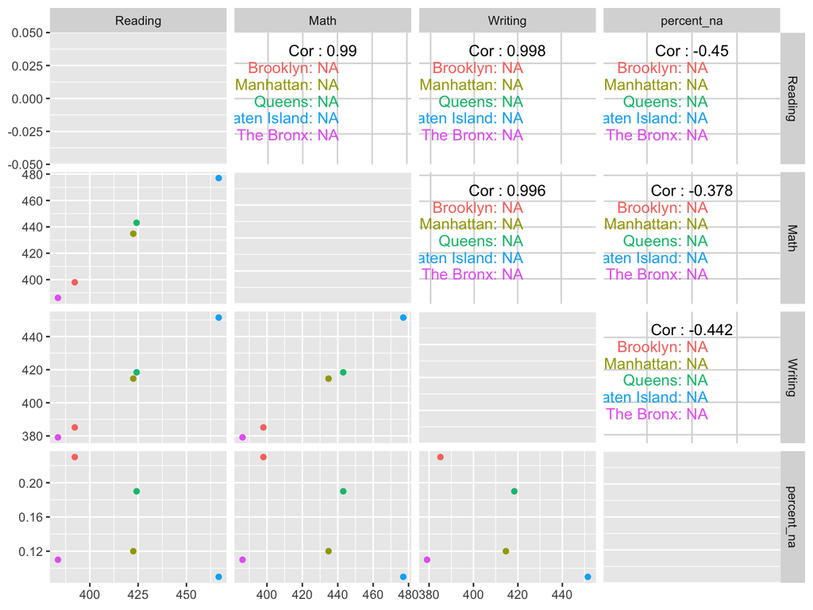

```r
ggpairs(dfsum, columns = 2:5, aes(color = BoroughName))
```